# Exercise 12.3

# Abstract

The goal here is to create a prediction model for the lead level over the Meuse River region

## Log-Transformation

# Preamble

## Import Library

The following code will automatically install packages that are not already installed and load them into the library:

```r
if(require('pacman')){
  library('pacman')
}else{
  install.packages('pacman')
  library('pacman')
}
pacman::p_load(sp, EnvStats, gstat, ggplot2, rmarkdown, reshape2, ggmap,
               RColorBrewer, parallel, dplyr, plotly, proj4, rgdal)
```

## Create Assignments

Note that meuse data set is included in the `sp` package and is not a data frame but an `sp` class, which is very similar to a data frame

```r
#Inspect the Data Set
data(meuse)
head(meuse)
```

|  | x | y | cadmium | copper | lead | zinc | elev | dist | om | ffreq | soil | lime | landuse | dist.m |
| --- | --- | --- | --- | --- | --- | --- | --- | --- | --- | --- | --- | --- | --- | --- |
| 1 | 181072 | 333611 | 11.7 | 85 | 299 | 1022 | 7.909 | 0.00135803 | 13.6 | 1 | 1 | 1 | Ah | 50 |
| 2 | 181025 | 333558 | 8.6 | 81 | 277 | 1141 | 6.983 | 0.01222430 | 14.0 | 1 | 1 | 1 | Ah | 30 |
| 3 | 181165 | 333537 | 6.5 | 68 | 199 | 640 | 7.800 | 0.10302900 | 13.0 | 1 | 1 | 1 | Ah | 150 |
| 4 | 181298 | 333484 | 2.6 | 81 | 116 | 257 | 7.655 | 0.19009400 | 8.0 | 1 | 2 | 0 | Ga | 270 |
| 5 | 181307 | 333330 | 2.8 | 48 | 117 | 269 | 7.480 | 0.27709000 | 8.7 | 1 | 2 | 0 | Ah | 380 |
| 6 | 181390 | 333260 | 3.0 | 61 | 137 | 281 | 7.791 | 0.36406700 | 7.8 | 1 | 2 | 0 | Ga | 470 |

```r
#Assignments
lon <- meuse$x
lat <- meuse$y
cd <- meuse$cadmium
cu <- meuse$copper
pb <- meuse$lead
zn <- meuse$zinc
```

# Lattitude and Longitude

- Lattitude is a line that runs east to west that measures how far north of the equatour a location is
  - Lattitude is assigned to the y-axis
- Longitude is a line that runs north to south that measures east/west
  - Longitude is assigned to the x-axis

# Assign the Co-ordinates

The *meuse* Data set is an `sp` class objects and requires for its co-ordinates to be set:

```r
rm(meuse); data(meuse)
coordinates(meuse) = ~x + y
```

The co-ordinate reference system is in meters north and meters east, this is going to be incompatible with the `ggmap` function, so it will have to be transformed first.

Because we are only plotting with base packages, pursuant to the lecture notes, we will leave the co-ordinate system in eastings and northings.

# Preliminary Step: Create a krige prediction Model

In order to create a krige prediction model two things are required:

- Fitted Variogram Model (e.g. an exponential model)
- A domain values over which to predict values

## Create a variogram Model

### Create a Variogram

Using an ordinary kriging method without any surface model provided:

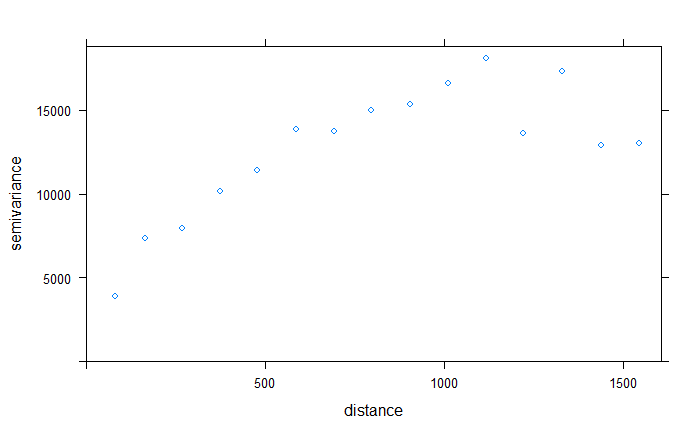

```r
lead.vg <- variogram(object = lead~1, data = meuse)
plot(lead.vg)
```

```r
head(lead.vg)
```

```
   np      dist     gamma dir.hor dir.ver   id
1  57  79.29244  3881.474       0       0 var1
2 299 163.97367  7317.871       0       0 var1
3 419 267.36483  7953.443       0       0 var1
4 457 372.73542 10144.515       0       0 var1
5 547 478.47670 11398.305       0       0 var1
6 533 585.34058 13874.912       0       0 var1
```

```r
#This is what would be used for the northing/easting CRS
lead.vg.fit <- fit.variogram(lead.vg, model = vgm(1, "Sph", 900, 1))
```

Thus the variogram model needed for the krige prediction has been ascertained

## Create a Grid of Domain values to use as predictor values

### Create a sequence of incrementally increasing for the X and Y axis

This will essentially act as the resolution of the overlay, Most monitors are about 140 ppi, hence assuming the plot will be a 9 inch square, about 800 x 800 pixels should look right, but 200 x 200 will be the used due to performance.

```r
xgrid       <-  seq(min(lon), max(lon), length.out = 200)
ygrid       <-  seq(min(lat), max(lat), length.out = 200)
```

### Combine into a domain base

This domain base however has to be a spatial object, this can be acheived by defining co-ordinates in the data frame

```r
xy.surface  <- expand.grid(lon = xgrid, lat = ygrid)
coordinates(xy.surface) = ~lon + lat
proj4string(xy.surface) <- proj4string(meuse)
head(xy.surface, 3)
```

```
SpatialPoints:
     lon    lat
1 178605 329714
2 178619 329714
3 178633 329714
Coordinate Reference System (CRS) arguments: NA
```

## Create the Krige prediction object

Krige predictions can be more accurate if the data is normally distributed.

Hence the case study used a log transformation on the *Zn* value, this is because the *Zn* value was non-normally distributed and the log transformation somewhat fixed that.

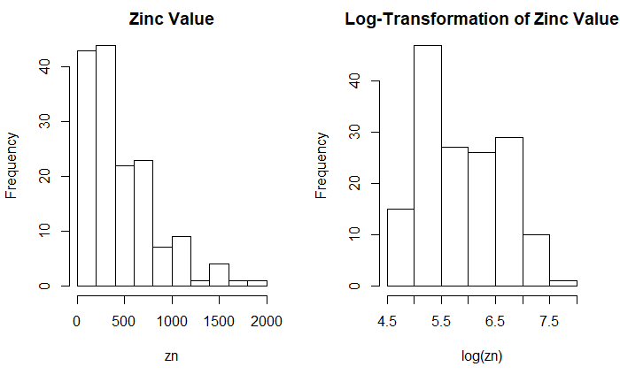

```r
par(mfcol = (c(1,2)))
hist(zn, main = "Zinc Value")
hist(log(zn), main = "Log-Transformation of Zinc Value")
```

An inspection of the *Pb* values shows that the log-transformation may be somewhat more normal, hence it will be used in the analysis.

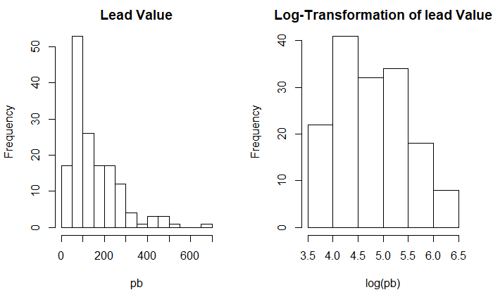

```r
par(mfcol = (c(1,2)))
hist(pb, main = "Lead Value")
hist(log(pb), main = "Log-Transformation of lead Value")
```

```r
lead.pred <- krige(formula = lead ~1,
                           locations =  meuse,
                           newdata = xy.surface,
                           model= lead.vg.fit.exp)
```

```
[using ordinary kriging]
```

```r
lead.log.pred = krige(log(lead)~1, meuse, xy.surface, model = lead.vg.fit)
```

```
[using ordinary kriging]
```

```r
lead.pred = krige(lead~1, meuse, xy.surface, model = lead.vg.fit)
```

```
[using ordinary kriging]
```

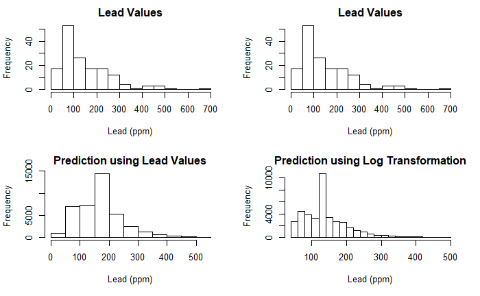

```r
par(mfcol = c(2,2))
hist(pb, main = "Lead Values",
     xlab = "Lead (ppm)")
hist(lead.pred$var1.pred, main = "Prediction using Lead Values",
     xlab = "Lead (ppm)")
hist(pb, main = "Lead Values",
     xlab = "Lead (ppm)")
hist(exp(lead.log.pred$var1.pred),
     main = "Prediction using Log Transformation",
     xlab = "Lead (ppm)")
```

```r
lead.log.pred$var1.pred <- exp(lead.log.pred$var1.pred)
head(lead.log.pred)
```

```
       coordinates var1.pred  var1.var
1 (178605, 329714)  187.7318 11133.651
2 (178619, 329714)  189.7963 10864.766
3 (178633, 329714)  191.9567 10591.846
4 (178647, 329714)  194.1952 10316.274
5 (178661, 329714)  196.4970 10039.840
6 (178675, 329714)  198.8397  9764.715
```

Now there is a prediction model, if that prediction model is extrapolated over our domain (`xy.surface`) the various plots can be created